# DSA6100: HW1 (Winter 2021)

##### **2.** This problem involves the Boston data set, which we saw in the lab for this chapter. We will now try to predict per capita crime rate using the other variables in this data set. In other words, per capita crime rate is the response, and the other variables are the predictors.

**(a)** For each predictor, fit a simple linear regression model to predict the response. Describe your results. In which of the models is there a statistically significant association between the predictor and the response? Create some plots to back up your assertions.

```r
library(MASS)
attach(Boston)
fit.zn <- lm(crim ~ zn)
summary(fit.zn)
```

```
##
## Call:
## lm(formula = crim ~ zn)
##
## Residuals:
##    Min     1Q Median     3Q    Max
## -4.429 -4.222 -2.620  1.250 84.523
##
## Coefficients:
##             Estimate Std. Error t value Pr(>|t|)
## (Intercept)  4.45369    0.41722  10.675  < 2e-16 ***
## zn          -0.07393    0.01609  -4.594 5.51e-06 ***
## ---
## Signif. codes:  0 '***' 0.001 '**' 0.01 '*' 0.05 '.' 0.1 ' ' 1
##
## Residual standard error: 8.435 on 504 degrees of freedom
## Multiple R-squared:  0.04019,    Adjusted R-squared:  0.03828
## F-statistic:  21.1 on 1 and 504 DF,  p-value: 5.506e-06
```

```r
fit.indus <- lm(crim ~ indus)
summary(fit.indus)
```

```
##
## Call:
## lm(formula = crim ~ indus)
##
## Residuals:
##     Min      1Q  Median      3Q     Max
## -11.972  -2.698  -0.736   0.712  81.813
##
## Coefficients:
##             Estimate Std. Error t value Pr(>|t|)
## (Intercept) -2.06374    0.66723  -3.093  0.00209 **
## indus        0.50978    0.05102   9.991  < 2e-16 ***
## ---
## Signif. codes:  0 '***' 0.001 '**' 0.01 '*' 0.05 '.' 0.1 ' ' 1
##
## Residual standard error: 7.866 on 504 degrees of freedom
## Multiple R-squared:  0.1653, Adjusted R-squared:  0.1637
## F-statistic: 99.82 on 1 and 504 DF,  p-value: < 2.2e-16
```

```r
chas <- as.factor(chas)
fit.chas <- lm(crim ~ chas)
summary(fit.chas)
```

```
##
## Call:
## lm(formula = crim ~ chas)
##
## Residuals:
##    Min     1Q Median     3Q    Max
## -3.738 -3.661 -3.435  0.018 85.232
##
## Coefficients:
##             Estimate Std. Error t value Pr(>|t|)
## (Intercept)   3.7444     0.3961   9.453   <2e-16 ***
## chas1        -1.8928     1.5061  -1.257    0.209
## ---
## Signif. codes:  0 '***' 0.001 '**' 0.01 '*' 0.05 '.' 0.1 ' ' 1
##
## Residual standard error: 8.597 on 504 degrees of freedom
## Multiple R-squared:  0.003124,   Adjusted R-squared:  0.001146
## F-statistic: 1.579 on 1 and 504 DF,  p-value: 0.2094
```

```r
fit.nox <- lm(crim ~ nox)
summary(fit.nox)
```

```
##
## Call:
## lm(formula = crim ~ nox)
##
## Residuals:
##     Min      1Q  Median      3Q     Max
## -12.371  -2.738  -0.974   0.559  81.728
##
## Coefficients:
##             Estimate Std. Error t value Pr(>|t|)
## (Intercept)  -13.720      1.699  -8.073 5.08e-15 ***
## nox           31.249      2.999  10.419  < 2e-16 ***
## ---
## Signif. codes:  0 '***' 0.001 '**' 0.01 '*' 0.05 '.' 0.1 ' ' 1
##
## Residual standard error: 7.81 on 504 degrees of freedom
## Multiple R-squared:  0.1772, Adjusted R-squared:  0.1756
## F-statistic: 108.6 on 1 and 504 DF,  p-value: < 2.2e-16
```

```r
fit.rm <- lm(crim ~ rm)
summary(fit.rm)
```

```
##
## Call:
## lm(formula = crim ~ rm)
##
## Residuals:
##    Min     1Q Median     3Q    Max
## -6.604 -3.952 -2.654  0.989 87.197
##
## Coefficients:
##             Estimate Std. Error t value Pr(>|t|)
## (Intercept)   20.482      3.365   6.088 2.27e-09 ***
## rm            -2.684      0.532  -5.045 6.35e-07 ***
## ---
## Signif. codes:  0 '***' 0.001 '**' 0.01 '*' 0.05 '.' 0.1 ' ' 1
##
## Residual standard error: 8.401 on 504 degrees of freedom
## Multiple R-squared:  0.04807,    Adjusted R-squared:  0.04618
## F-statistic: 25.45 on 1 and 504 DF,  p-value: 6.347e-07
```

```r
fit.age <- lm(crim ~ age)
summary(fit.age)
```

```
##
## Call:
## lm(formula = crim ~ age)
##
## Residuals:
##    Min     1Q Median     3Q    Max
## -6.789 -4.257 -1.230  1.527 82.849
##
## Coefficients:
##             Estimate Std. Error t value Pr(>|t|)
## (Intercept) -3.77791    0.94398  -4.002 7.22e-05 ***
## age          0.10779    0.01274   8.463 2.85e-16 ***
## ---
## Signif. codes:  0 '***' 0.001 '**' 0.01 '*' 0.05 '.' 0.1 ' ' 1
##
## Residual standard error: 8.057 on 504 degrees of freedom
## Multiple R-squared:  0.1244, Adjusted R-squared:  0.1227
## F-statistic: 71.62 on 1 and 504 DF,  p-value: 2.855e-16
```

```r
fit.dis <- lm(crim ~ dis)
summary(fit.dis)
```

```
##
## Call:
## lm(formula = crim ~ dis)
##
## Residuals:
##    Min     1Q Median     3Q    Max
## -6.708 -4.134 -1.527  1.516 81.674
##
## Coefficients:
##             Estimate Std. Error t value Pr(>|t|)
## (Intercept)   9.4993     0.7304  13.006   <2e-16 ***
## dis          -1.5509     0.1683  -9.213   <2e-16 ***
## ---
## Signif. codes:  0 '***' 0.001 '**' 0.01 '*' 0.05 '.' 0.1 ' ' 1
##
## Residual standard error: 7.965 on 504 degrees of freedom
## Multiple R-squared:  0.1441, Adjusted R-squared:  0.1425
## F-statistic: 84.89 on 1 and 504 DF,  p-value: < 2.2e-16
```

```r
fit.rad <- lm(crim ~ rad)
summary(fit.rad)
```

```
##
## Call:
## lm(formula = crim ~ rad)
##
## Residuals:
##     Min      1Q  Median      3Q     Max
## -10.164  -1.381  -0.141   0.660  76.433
##
## Coefficients:
##             Estimate Std. Error t value Pr(>|t|)
## (Intercept) -2.28716    0.44348  -5.157 3.61e-07 ***
## rad          0.61791    0.03433  17.998  < 2e-16 ***
## ---
## Signif. codes:  0 '***' 0.001 '**' 0.01 '*' 0.05 '.' 0.1 ' ' 1
##
## Residual standard error: 6.718 on 504 degrees of freedom
## Multiple R-squared:  0.3913, Adjusted R-squared:   0.39
## F-statistic: 323.9 on 1 and 504 DF,  p-value: < 2.2e-16
```

```r
fit.tax <- lm(crim ~ tax)
summary(fit.tax)
```

```
##
## Call:
## lm(formula = crim ~ tax)
##
## Residuals:
##     Min      1Q  Median      3Q     Max
## -12.513  -2.738  -0.194   1.065  77.696
##
## Coefficients:
##              Estimate Std. Error t value Pr(>|t|)
## (Intercept) -8.528369   0.815809  -10.45   <2e-16 ***
## tax          0.029742   0.001847   16.10   <2e-16 ***
## ---
## Signif. codes:  0 '***' 0.001 '**' 0.01 '*' 0.05 '.' 0.1 ' ' 1
##
## Residual standard error: 6.997 on 504 degrees of freedom
## Multiple R-squared:  0.3396, Adjusted R-squared:  0.3383
## F-statistic: 259.2 on 1 and 504 DF,  p-value: < 2.2e-16
```

```r
fit.ptratio <- lm(crim ~ ptratio)
summary(fit.ptratio)
```

```
##
## Call:
## lm(formula = crim ~ ptratio)
##
## Residuals:
##    Min     1Q Median     3Q    Max
## -7.654 -3.985 -1.912  1.825 83.353
##
## Coefficients:
##             Estimate Std. Error t value Pr(>|t|)
## (Intercept) -17.6469     3.1473  -5.607 3.40e-08 ***
## ptratio       1.1520     0.1694   6.801 2.94e-11 ***
## ---
## Signif. codes:  0 '***' 0.001 '**' 0.01 '*' 0.05 '.' 0.1 ' ' 1
##
## Residual standard error: 8.24 on 504 degrees of freedom
## Multiple R-squared:  0.08407,    Adjusted R-squared:  0.08225
## F-statistic: 46.26 on 1 and 504 DF,  p-value: 2.943e-11
```

```r
fit.black <- lm(crim ~ black)
summary(fit.black)
```

```
##
## Call:
## lm(formula = crim ~ black)
##
## Residuals:
##     Min      1Q  Median      3Q     Max
## -13.756  -2.299  -2.095  -1.296  86.822
##
## Coefficients:
##              Estimate Std. Error t value Pr(>|t|)
## (Intercept) 16.553529   1.425903  11.609   <2e-16 ***
## black       -0.036280   0.003873  -9.367   <2e-16 ***
## ---
## Signif. codes:  0 '***' 0.001 '**' 0.01 '*' 0.05 '.' 0.1 ' ' 1
##
## Residual standard error: 7.946 on 504 degrees of freedom
## Multiple R-squared:  0.1483, Adjusted R-squared:  0.1466
## F-statistic: 87.74 on 1 and 504 DF,  p-value: < 2.2e-16
```

```r
fit.lstat <- lm(crim ~ lstat)
summary(fit.lstat)
```

```
##
## Call:
## lm(formula = crim ~ lstat)
##
## Residuals:
##     Min      1Q  Median      3Q     Max
## -13.925  -2.822  -0.664   1.079  82.862
##
## Coefficients:
##             Estimate Std. Error t value Pr(>|t|)
## (Intercept) -3.33054    0.69376  -4.801 2.09e-06 ***
## lstat        0.54880    0.04776  11.491  < 2e-16 ***
## ---
## Signif. codes:  0 '***' 0.001 '**' 0.01 '*' 0.05 '.' 0.1 ' ' 1
##
## Residual standard error: 7.664 on 504 degrees of freedom
## Multiple R-squared:  0.2076, Adjusted R-squared:  0.206
## F-statistic:   132 on 1 and 504 DF,  p-value: < 2.2e-16
```

```r
fit.medv <- lm(crim ~ medv)
summary(fit.medv)
```

```
##
## Call:
## lm(formula = crim ~ medv)
##
## Residuals:
##    Min     1Q Median     3Q    Max
## -9.071 -4.022 -2.343  1.298 80.957
##
## Coefficients:
##             Estimate Std. Error t value Pr(>|t|)
## (Intercept) 11.79654    0.93419   12.63   <2e-16 ***
## medv        -0.36316    0.03839   -9.46   <2e-16 ***
## ---
## Signif. codes:  0 '***' 0.001 '**' 0.01 '*' 0.05 '.' 0.1 ' ' 1
##
## Residual standard error: 7.934 on 504 degrees of freedom
## Multiple R-squared:  0.1508, Adjusted R-squared:  0.1491
## F-statistic: 89.49 on 1 and 504 DF,  p-value: < 2.2e-16
```

*Except for **chas**, the p-value for all predictors is less than 0.05, so we may conclude that other than **chas** all other predictors are statistically significant. So we may not reject the null hypothesis for the predictor **chas**.*

##### Plots to back up the assertions:

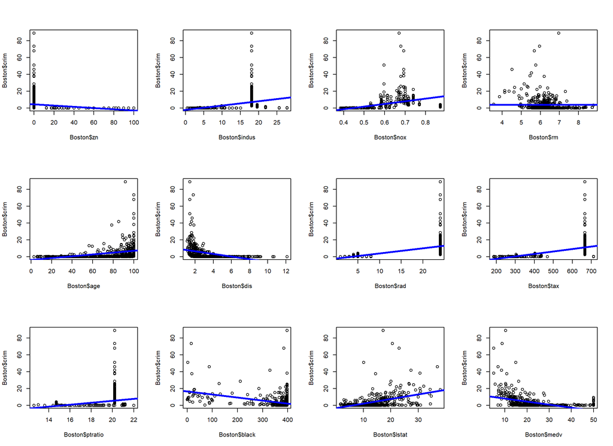

```r
par(mfrow=c(3,4))
plot(Boston$zn, Boston$crim)
abline(fit.zn, col="blue",lwd=3)
plot(Boston$indus, Boston$crim)
abline(fit.indus, col="blue",lwd=3)
plot(Boston$nox, Boston$crim)
abline(fit.nox, col="blue",lwd=3)
plot(Boston$rm, Boston$crim)
abline(fit.zn, col="blue",lwd=3)
plot(Boston$age, Boston$crim)
abline(fit.age, col="blue",lwd=3)
plot(Boston$dis, Boston$crim)
abline(fit.dis, col="blue",lwd=3)
plot(Boston$rad, Boston$crim)
abline(fit.rad, col="blue",lwd=3)
plot(Boston$tax, Boston$crim)
abline(fit.tax, col="blue",lwd=3)
plot(Boston$ptratio, Boston$crim)
abline(fit.ptratio, col="blue",lwd=3)
plot(Boston$black, Boston$crim)
abline(fit.black, col="blue",lwd=3)
plot(Boston$lstat, Boston$crim)
abline(fit.lstat, col="blue",lwd=3)
plot(Boston$medv, Boston$crim)
abline(fit.medv, col="blue",lwd=3)
```

##### No effect predictor: **chas**

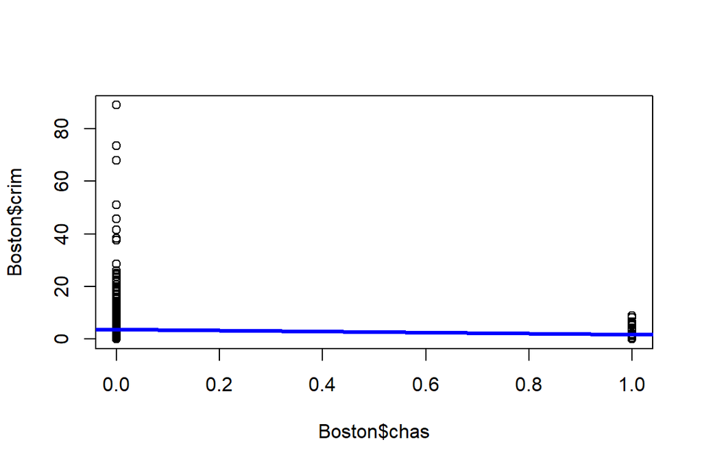

```r
plot(Boston$chas, Boston$crim)
abline(fit.chas, col="blue",lwd=3)
```

**(b)** Fit a multiple regression model to predict the response usingall of the predictors. Describe your results. For which predictors can we reject the null hypothesis 𝐻0:𝛽𝑗=0?

```r
fit.all <- lm(crim ~ ., data = Boston)
summary(fit.all)
```

```
##
## Call:
## lm(formula = crim ~ ., data = Boston)
##
## Residuals:
##    Min     1Q Median     3Q    Max
## -9.924 -2.120 -0.353  1.019 75.051
##
## Coefficients:
##               Estimate Std. Error t value Pr(>|t|)
## (Intercept)  17.033228   7.234903   2.354 0.018949 *
## zn            0.044855   0.018734   2.394 0.017025 *
## indus        -0.063855   0.083407  -0.766 0.444294
## chas         -0.749134   1.180147  -0.635 0.525867
## nox         -10.313535   5.275536  -1.955 0.051152 .
## rm            0.430131   0.612830   0.702 0.483089
## age           0.001452   0.017925   0.081 0.935488
## dis          -0.987176   0.281817  -3.503 0.000502 ***
## rad           0.588209   0.088049   6.680 6.46e-11 ***
## tax          -0.003780   0.005156  -0.733 0.463793
## ptratio      -0.271081   0.186450  -1.454 0.146611
## black        -0.007538   0.003673  -2.052 0.040702 *
## lstat         0.126211   0.075725   1.667 0.096208 .
## medv         -0.198887   0.060516  -3.287 0.001087 **
## ---
## Signif. codes:  0 '***' 0.001 '**' 0.01 '*' 0.05 '.' 0.1 ' ' 1
##
## Residual standard error: 6.439 on 492 degrees of freedom
## Multiple R-squared:  0.454,  Adjusted R-squared:  0.4396
## F-statistic: 31.47 on 13 and 492 DF,  p-value: < 2.2e-16
```

*We may reject the null hypothesis for *zn*, *dis*, *rad*, *black* and *medv* as these variables were found to be statistically significant with p-values less than .05.*

**(c)** How do your results from (a) compare to your results from (b)?Create a plot displaying the univariate regression coefficients from (a) on the x-axis, and the multiple regression coefficients from (b) on the y-axis. That is, each predictor is displayed as a single point in the plot. Its coefficient in a simple linear regression model is shown on the x-axis, and its coefficient estimate in the multiple linear regression model is shown on the y-axis.

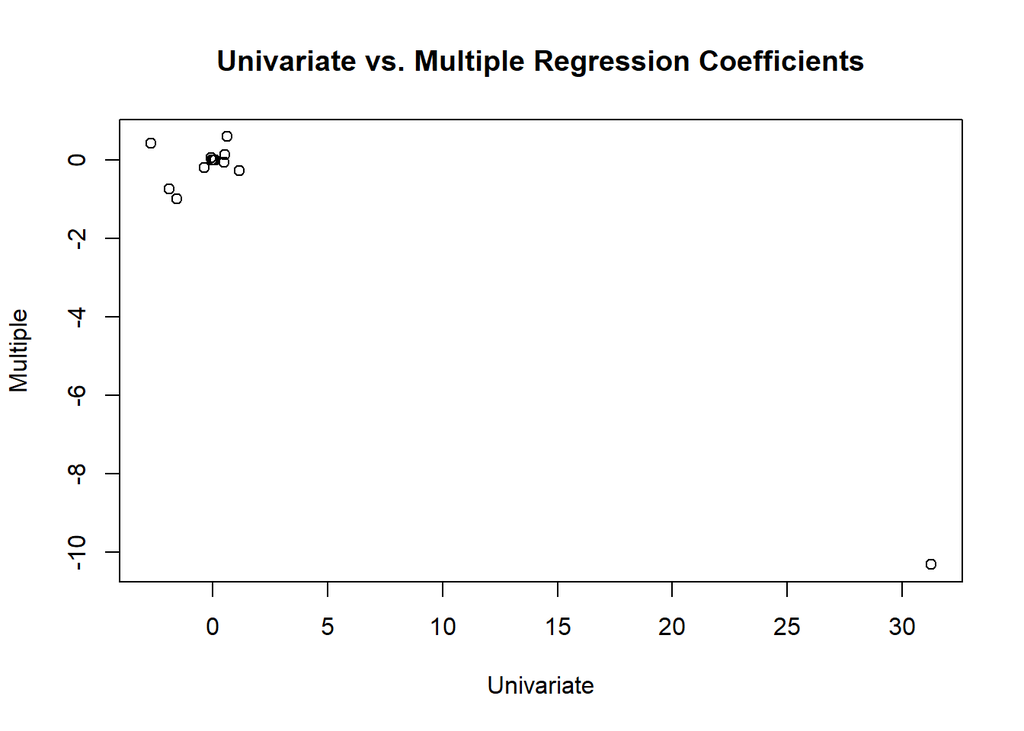

```r
x = c(coefficients(fit.zn)[2],
      coefficients(fit.indus)[2],
      coefficients(fit.chas)[2],
      coefficients(fit.nox)[2],
      coefficients(fit.rm)[2],
      coefficients(fit.age)[2],
      coefficients(fit.dis)[2],
      coefficients(fit.rad)[2],
      coefficients(fit.tax)[2],
      coefficients(fit.ptratio)[2],
      coefficients(fit.black)[2],
      coefficients(fit.lstat)[2],
      coefficients(fit.medv)[2])
y = coefficients(fit.all)[2:14]
plot(x, y, main = "Univariate vs. Multiple Regression Coefficients", xlab = "Univariate", ylab = "Multiple")
```

##### **3.** Question 3. Assume the data X1, X2, and Y are listed as follows.

```r
X1 <- c(-0.51,  0.98, -0.41,  0.00, -0.54, -0.76,  0.57, -0.71)
X1
```

```
## [1] -0.51  0.98 -0.41  0.00 -0.54 -0.76  0.57 -0.71
```

```r
X2 <- c(0.48, -0.28, -0.37,  0.15, -0.34,  0.44, -0.96, -0.17)
X2
```

```
## [1]  0.48 -0.28 -0.37  0.15 -0.34  0.44 -0.96 -0.17
```

```r
Y <- c(-0.50,  1.43, -0.78,  0.07, -0.95, -0.86,  0.41, -1.10)
Y
```

```
## [1] -0.50  1.43 -0.78  0.07 -0.95 -0.86  0.41 -1.10
```

**(a)** Fit linear regression model Y = β^0 + β^1 X^1, show the estimated values of parameters,and R2.Test the null hypothesis 𝐻0:𝛽𝑗=0

```r
fit.lm1 <- lm(Y ~ X1)
summary(fit.lm1)
```

```
##
## Call:
## lm(formula = Y ~ X1)
##
## Residuals:
##      Min       1Q   Median       3Q      Max
## -0.28610 -0.17985  0.01115  0.19443  0.23096
##
## Coefficients:
##             Estimate Std. Error t value Pr(>|t|)
## (Intercept) -0.05707    0.08295  -0.688    0.517
## X1           1.32135    0.13353   9.895 6.15e-05 ***
## ---
## Signif. codes:  0 '***' 0.001 '**' 0.01 '*' 0.05 '.' 0.1 ' ' 1
##
## Residual standard error: 0.2254 on 6 degrees of freedom
## Multiple R-squared:  0.9423, Adjusted R-squared:  0.9326
## F-statistic: 97.92 on 1 and 6 DF,  p-value: 6.15e-05
```

*Estimated values of coefficients β0, β1 are respectively -0.05707 and 1.32135.*

*Multiple R-squared: 0.9423, Adjusted R-squared: 0.9326.*

*We may reject the null hypothesis H0 for β1 as the p-value is less than 0.05.*

**(b)** Fit linear regression model Y = β^0 + β^1 X^1 + β^2 X^2,show the estimated values of parameters, and R2.Test the null hypothesis 𝐻0:𝛽𝑗=0

```r
fit.lm2 <- lm(Y ~ X1+X2)
summary(fit.lm2)
```

```
##
## Call:
## lm(formula = Y ~ X1 + X2)
##
## Residuals:
##         1         2         3         4         5         6         7         8
## -0.013253  0.035374 -0.011195 -0.051508  0.001507  0.028023 -0.012545  0.023596
##
## Coefficients:
##             Estimate Std. Error t value Pr(>|t|)
## (Intercept)  0.04485    0.01394   3.218   0.0235 *
## X1           1.52334    0.02359  64.582 1.69e-08 ***
## X2           0.51105    0.03157  16.187 1.64e-05 ***
## ---
## Signif. codes:  0 '***' 0.001 '**' 0.01 '*' 0.05 '.' 0.1 ' ' 1
##
## Residual standard error: 0.03378 on 5 degrees of freedom
## Multiple R-squared:  0.9989, Adjusted R-squared:  0.9985
## F-statistic:  2310 on 2 and 5 DF,  p-value: 3.844e-08
```

*Estimated values of coefficients β0, β1, and β2 are respectively 0.04485, 1.52334, and 0.51105.*

*Multiple R-squared: 0.9989, Adjusted R-squared: 0.9985.*

*We may reject the null hypothesis H0 for β1 & β2 as the p-value is less than 0.05.*